# Hierarchical Clustering Workbook

Machine Learning

9/8/2021

In this workbook we will cover an introduction the hierarchical clustering method in R. Hierarchical clustering is a very useful method for identifying groups in a dataset. One of its key strengths is that it does not require us to specify the number of clusters used prior to applying the algorithm. Instead we can view the dendrogram, visualize the structure of the dataset and then choose the number of clusters to use.

Lets first load the packages we will use for this analysis:

```r
# install.packages("cluster")
# install.packages("factoextra")
# install.packages("dendextend")
# install.packages("circlize")
library(cluster)    # clustering algorithms
library(factoextra) # clustering visualization
```

```r
library(dendextend) # for comparing two dendrograms
library(circlize) # For circular dendrograms
```

The type of hierarchical clustering we will focus on is called agglormerative clustering. Here we start with each sample as its own cluster and work from the bottom up, at each step of the algorithm the two clusters most similar to each other are joined and combined into a new bigger cluster. It is also possible to work from the top down and split the data from one large cluster into smaller clusters and eventually their own cluster.

### Data

The data we are going to use for this analysis is the `USArrests` data, this dataset contains information on the number of arrests per 100,000 residents in each US state for assault, murder and rape as well as the percentage of the population living in urban areas. This is a built in dataset in R, so to access it we can just run:

```r
# Assign built in data frame
data <- USArrests
```

Lets view the data:

```r
head(data)
```

```
##            Murder Assault UrbanPop Rape
## Alabama      13.2     236       58 21.2
## Alaska       10.0     263       48 44.5
## Arizona       8.1     294       80 31.0
## Arkansas      8.8     190       50 19.5
## California    9.0     276       91 40.6
## Colorado      7.9     204       78 38.7
```

```r
tail(data)
```

```
##               Murder Assault UrbanPop Rape
## Vermont          2.2      48       32 11.2
## Virginia         8.5     156       63 20.7
## Washington       4.0     145       73 26.2
## West Virginia    5.7      81       39  9.3
## Wisconsin        2.6      53       66 10.8
## Wyoming          6.8     161       60 15.6
```

```r
dim(data)
```

```
## [1] 50  4
```

As we can see the data contains samples for 50 states and has 4 variables. The state is indicated by the rowname of the data. Lets view a summary of the data:

```r
summary(data)
```

```
##      Murder          Assault         UrbanPop          Rape
##  Min.   : 0.800   Min.   : 45.0   Min.   :32.00   Min.   : 7.30
##  1st Qu.: 4.075   1st Qu.:109.0   1st Qu.:54.50   1st Qu.:15.07
##  Median : 7.250   Median :159.0   Median :66.00   Median :20.10
##  Mean   : 7.788   Mean   :170.8   Mean   :65.54   Mean   :21.23
##  3rd Qu.:11.250   3rd Qu.:249.0   3rd Qu.:77.75   3rd Qu.:26.18
##  Max.   :17.400   Max.   :337.0   Max.   :91.00   Max.   :46.00
```

### Hierarchical Clustering

Our objective in this analysis is to identify groups of similar states in the US. For this we will use hierarchical clustering which can be run using the function `hclust()`. Prior to running hierarchical clustering we will need to calculate the distance between the points in our dataset. For clustering it is often beneficial to scale the features prior to analysis so that they have equal weight in the clustering solution.

Lets first scale the data:

```r
# Scale data
sdata <- scale(data)
```

We can now view a summary of the data to ensure the scaling has worked correctly:

```r
# summarize scaled data
summary(sdata)
```

```
##      Murder           Assault           UrbanPop             Rape
##  Min.   :-1.6044   Min.   :-1.5090   Min.   :-2.31714   Min.   :-1.4874
##  1st Qu.:-0.8525   1st Qu.:-0.7411   1st Qu.:-0.76271   1st Qu.:-0.6574
##  Median :-0.1235   Median :-0.1411   Median : 0.03178   Median :-0.1209
##  Mean   : 0.0000   Mean   : 0.0000   Mean   : 0.00000   Mean   : 0.0000
##  3rd Qu.: 0.7949   3rd Qu.: 0.9388   3rd Qu.: 0.84354   3rd Qu.: 0.5277
##  Max.   : 2.2069   Max.   : 1.9948   Max.   : 1.75892   Max.   : 2.6444
```

We see now that each of our features has the mean value 0 and if we calculated it, would have a standard deviation of 1.

Next we need to calculate the distance between the samples in our dataset. We can do this using the `dist()` function. For this analysis we will use Euclidean distance. However if we wished to use other distances we could change the method function.

```r
# Calculate distances between points
dist_mat <- dist(sdata, # Set dataset
                 method = "euclidean") # Set distance measure to use
```

We can now run our hierarchical clustering algorithm using the calculated distance matrix and the function `hclust`. There are several different linkage methods we can use to tell the algorithm how to deal with joining clusters with multiple samples. For this initial model we will use average linkage, which uses the average distance between all of the points in each cluster as the dissimilarity measure between clusters.

```r
# Run hierarchical clustering
hc <- hclust(dist_mat, # Set distance matrix to use
              method = "average" ) # Set linkage measure to use
```

We can then plot the dendrogram produced by this clustering use the `plot()` function:

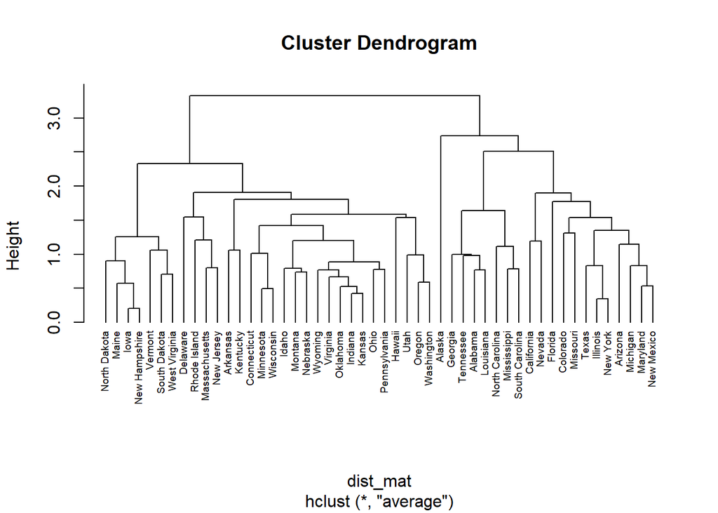

```r
plot(hc, # Set hierarchical clustering as plot object
     cex = 0.6, # Set text size
     hang = -1 ) # Set label position
```

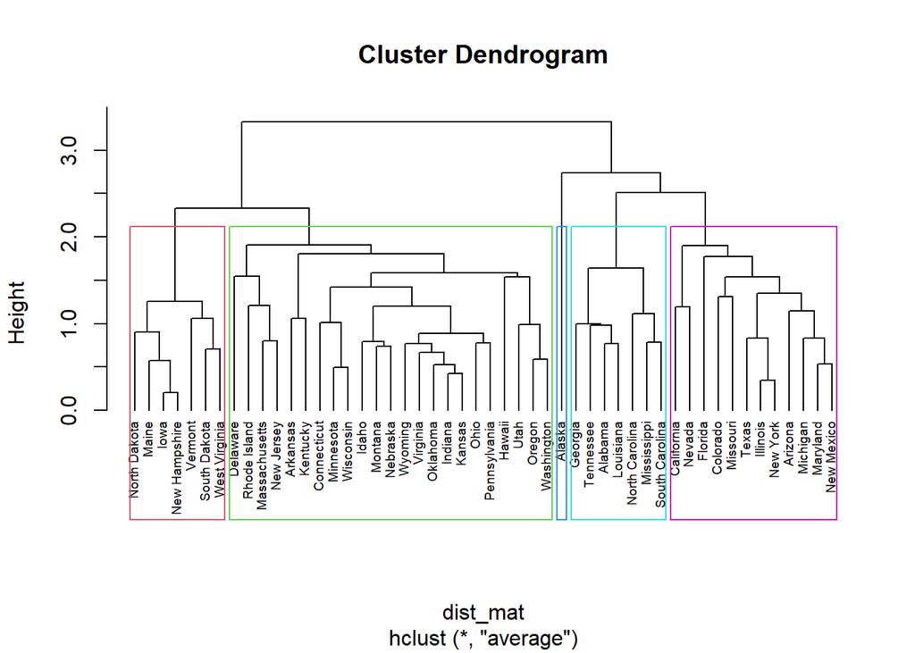

```r
plot(hc, # Set hierarchical clustering as plot object
     cex = 0.6,  # Set text size
     hang = -1) # Set label position
# Draw rectangles around branches/clusters
rect.hclust(hc, # Set hierarchical clustering object
            k = 5, # Set number of clusters
            border = 2:6) # Sets colors for rectangles
```

We can also plot a nicer looking dendrogram using the dendextend package:

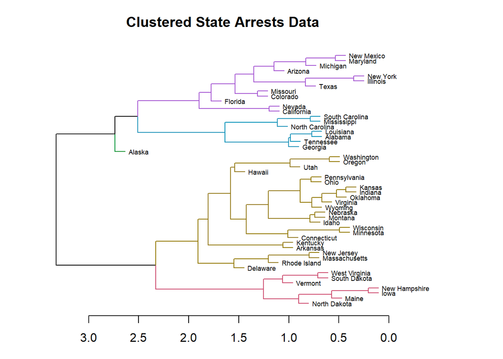

```r
# Create dendrogram
dend <- as.dendrogram(hc)
# order it the closest we can to the order of the observations:
dend <- rotate(dend, 1:50)

# Color the branches based on the clusters:
dend <- color_branches(dend, k=5)

# We hang the dendrogram a bit:
dend <- hang.dendrogram(dend,hang_height=0.1)
# reduce the size of the labels:
dend <- set(dend, "labels_cex", 0.55)
# And plot:
par(mar = c(3,3,3,7))
plot(dend,
     main = "Clustered State Arrests Data",
     horiz =  TRUE,  nodePar = list(cex = .007))
```

We can also plot this in a circular fashion:

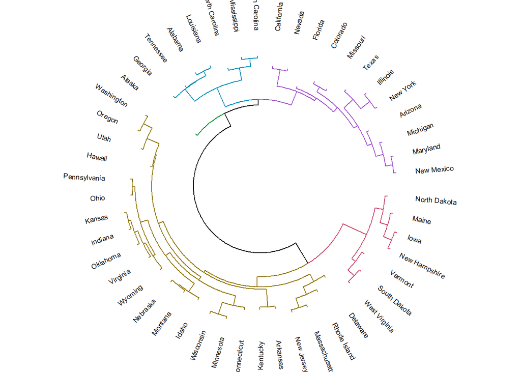

```r
par(mar = rep(0,4))
circlize_dendrogram(dend)
```

To extract the clusters from the hierarchical clustering algorithm we can use the `cutree()` function. Here we will extract 5 clusters, however it is also possible to set the parameter `h` which will cut the dendrogram at a certain height.

```r
clusters <- cutree(hc, # Specify object
                   k = 5) # Specify number of clusters
```

It is also possible to visualize the data and clusters in two dimensional space using the `fviz_cluster()`. For this we use the clusters we have extracted:

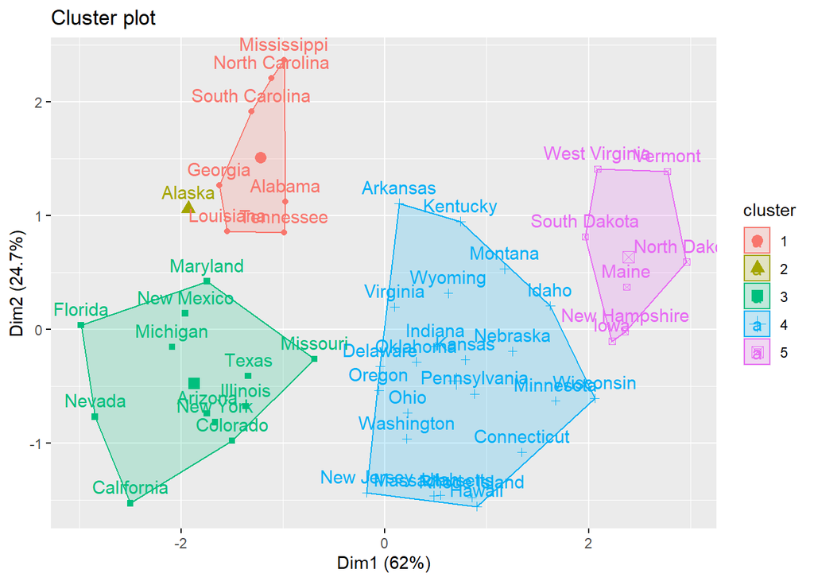

```r
fviz_cluster(list(data = data, # Set data
                  cluster = clusters)) # Set clusters
```

### Other linkage measures

Lets try some other linkage measures and see how they perform for this dataset. Here we will use complete linkage which uses the distance between the two furthest points in the cluster to calculate the distance between them and single linkage which uses the two closest points:

```r
# Run hierarchical clustering
hc_1 <- hclust(dist_mat, # Set distance matrix to use
              method = "complete" ) # Set linkage measure to use
# Run hierarchical clustering
hc_2 <- hclust(dist_mat, # Set distance matrix to use
              method = "single" ) # Set linkage measure to use
```

Lets plot the dendrograms for these two trees:

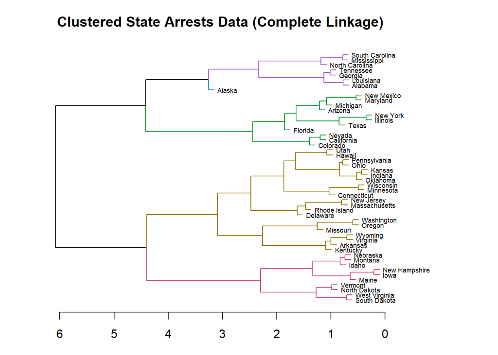

```r
# Create dendrogram
dend_1 <- as.dendrogram(hc_1)
# order it the closest we can to the order of the observations:
dend_1 <- rotate(dend_1, 1:50)

# Color the branches based on the clusters:
dend_1 <- color_branches(dend_1, k=5)

# We hang the dendrogram a bit:
dend_1 <- hang.dendrogram(dend_1,hang_height=0.1)
# reduce the size of the labels:
dend_1 <- set(dend_1, "labels_cex", 0.55)
# And plot:
par(mar = c(3,3,3,7))
plot(dend_1,
     main = "Clustered State Arrests Data (Complete Linkage)",
     horiz =  TRUE,  nodePar = list(cex = .007))
```

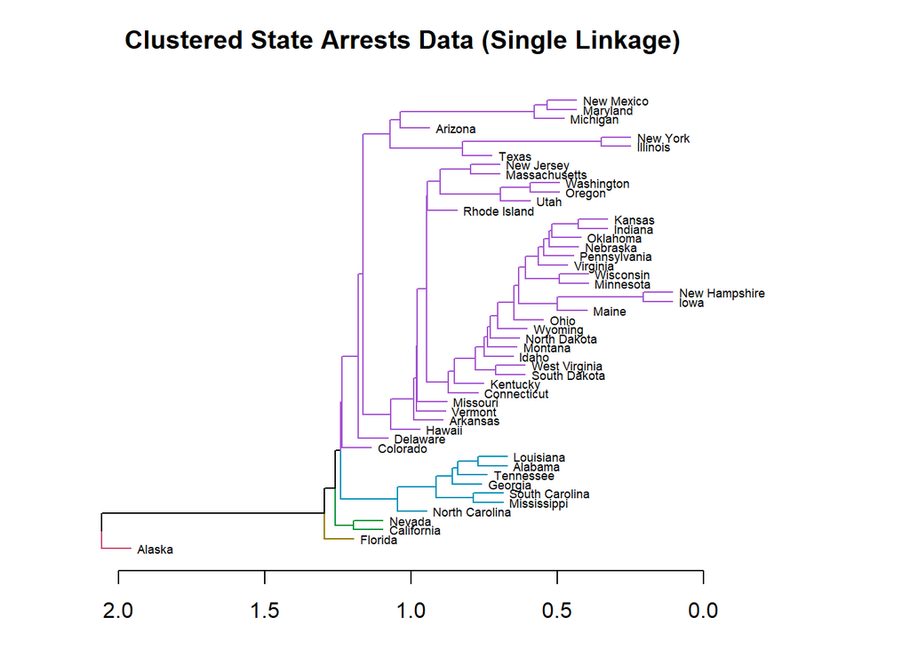

```r
# Create dendrogram
dend_2 <- as.dendrogram(hc_2)
# order it the closest we can to the order of the observations:
dend_2 <- rotate(dend_2, 1:50)

# Color the branches based on the clusters:
dend_2 <- color_branches(dend_2, k=5)

# We hang the dendrogram a bit:
dend_2 <- hang.dendrogram(dend_2,hang_height=0.1)
# reduce the size of the labels:
dend_2 <- set(dend_2, "labels_cex", 0.55)
# And plot:
par(mar = c(3,3,3,7))
plot(dend_2,
     main = "Clustered State Arrests Data (Single Linkage)",
     horiz =  TRUE,  nodePar = list(cex = .007))
```

As can be seen from the plots, complete linkage gives a result quite similar to average linkage while single linkage leads to a chaining effect.

We can then compare the results given from these two measures using `tanglegram()` which plots two dendrograms side by side:

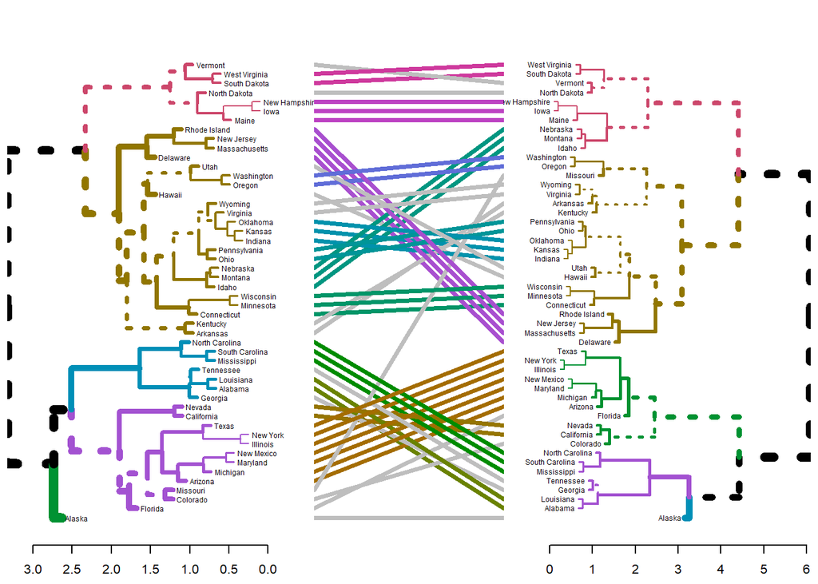

```r
# Compare average and complete linkage
tanglegram(dend, dend_1, sort = TRUE)
```

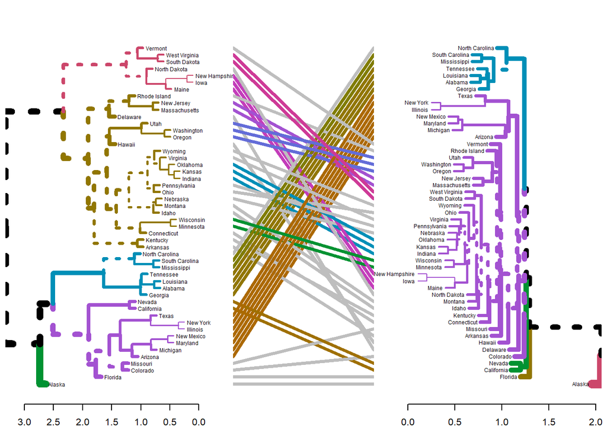

```r
# Compare average and single linkage
tanglegram(dend, dend_2, sort = TRUE)
```

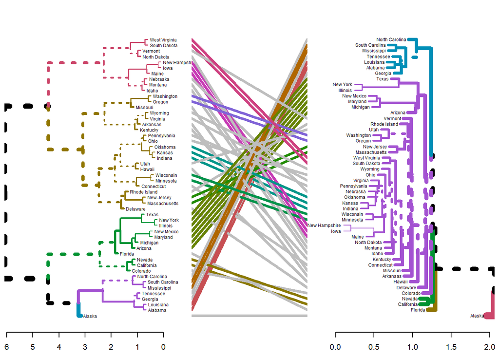

```r
# Compare complete and single linkage
tanglegram(dend_1, dend_2, sort = TRUE)
```

## Exercises

For this analysis we will be looking at coffees from different parts of the world. The data is averaged to a country level to give an overall idea of the types of coffee coming from each country. Let’s load the data in:

```r
# Load dataset
load("coffee_data.rda")
```

Let’s view the data:

```r
head(coffee_data) # View first rows of coffe data
```

```
##                           Aroma   Flavor Aftertaste  Acidity     Body  Balance
## Ethiopia               7.964333 8.088667   7.958667 8.069667 7.930000 8.026000
## Guatemala              7.579167 7.532692   7.294615 7.620513 7.484679 7.485577
## United States          7.886250 8.136250   7.988750 8.063750 7.937500 7.947500
## United States (Hawaii) 8.330000 8.295000   7.915000 8.125000 8.000000 7.915000
## Indonesia              7.666667 7.564444   7.412222 7.480556 7.648333 7.512778
## China                  7.641250 7.625625   7.484375 7.578125 7.573750 7.548125
##                        Uniformity Clean.Cup Sweetness Cupper.Points
## Ethiopia                 9.910667  9.977667  9.866333      8.124667
## Guatemala                9.871603  9.875897  9.854487      7.407756
## United States           10.000000 10.000000 10.000000      8.021250
## United States (Hawaii)  10.000000 10.000000 10.000000      8.375000
## Indonesia                9.925556  9.962778  9.962778      7.388889
## China                    9.958125  9.958125  9.916250      7.646875
##                        Total.Cup.Points   Moisture Category.One.Defects
## Ethiopia                       85.91633 0.08100000            0.3666667
## Guatemala                      82.00679 0.10307692            0.2179487
## United States                  85.97875 0.00000000            0.0000000
## United States (Hawaii)         86.96000 0.00000000            0.0000000
## Indonesia                      82.52833 0.09666667            0.3333333
## China                          82.92750 0.09437500            0.0000000
```

```r
tail(coffee_data) # View tail of coffee data
```

```
##                  Aroma Flavor Aftertaste  Acidity     Body  Balance Uniformity
## Laos          7.503333 7.5000      7.280 7.306667 7.363333 7.416667      10.00
## Zambia        7.670000 7.0800      7.420 7.330000 7.750000 7.420000      10.00
## Myanmar       7.303750 7.3325      7.125 7.406250 7.270000 7.133750      10.00
## Mauritius     7.250000 7.2500      7.170 7.170000 7.250000 7.170000      10.00
## Cote d?Ivoire 7.420000 7.2500      6.830 7.000000 7.330000 7.080000       9.33
## Peru          7.545000 7.4600      7.250 7.460000 7.960000 7.665000       8.67
##               Clean.Cup Sweetness Cupper.Points Total.Cup.Points   Moisture
## Laos              10.00     10.00        7.4700         81.83333 0.08333333
## Zambia            10.00     10.00        7.2500         81.92000 0.00000000
## Myanmar           10.00     10.00        7.1775         80.75000 0.01375000
## Mauritius         10.00     10.00        7.2500         80.50000 0.12000000
## Cote d?Ivoire     10.00     10.00        7.0800         79.33000 0.13000000
## Peru               7.33      9.33        7.3350         78.00000 0.00000000
##               Category.One.Defects
## Laos                         0.000
## Zambia                       1.000
## Myanmar                      0.125
## Mauritius                    0.000
## Cote d?Ivoire                1.000
## Peru                         3.500
```

```r
summary(coffee_data) # Summarize coffee data
```

```
##      Aroma           Flavor        Aftertaste       Acidity
##  Min.   :7.153   Min.   :6.998   Min.   :6.830   Min.   :7.000
##  1st Qu.:7.451   1st Qu.:7.382   1st Qu.:7.254   1st Qu.:7.407
##  Median :7.579   Median :7.529   Median :7.420   Median :7.491
##  Mean   :7.609   Mean   :7.565   Mean   :7.442   Mean   :7.547
##  3rd Qu.:7.669   3rd Qu.:7.662   3rd Qu.:7.587   3rd Qu.:7.672
##  Max.   :8.330   Max.   :8.420   Max.   :7.989   Max.   :8.330
##       Body          Balance        Uniformity       Clean.Cup
##  Min.   :7.227   Min.   :7.057   Min.   : 8.670   Min.   : 7.330
##  1st Qu.:7.364   1st Qu.:7.407   1st Qu.: 9.761   1st Qu.: 9.873
##  Median :7.574   Median :7.547   Median : 9.943   Median : 9.981
##  Mean   :7.580   Mean   :7.556   Mean   : 9.810   Mean   : 9.789
##  3rd Qu.:7.733   3rd Qu.:7.740   3rd Qu.:10.000   3rd Qu.:10.000
##  Max.   :8.080   Max.   :8.250   Max.   :10.000   Max.   :10.000
##    Sweetness      Cupper.Points   Total.Cup.Points    Moisture
##  Min.   : 9.112   Min.   :7.013   Min.   :77.18    Min.   :0.00000
##  1st Qu.: 9.866   1st Qu.:7.323   1st Qu.:81.29    1st Qu.:0.06495
##  Median : 9.985   Median :7.570   Median :82.31    Median :0.08609
##  Mean   : 9.889   Mean   :7.555   Mean   :82.34    Mean   :0.08104
##  3rd Qu.:10.000   3rd Qu.:7.681   3rd Qu.:83.47    3rd Qu.:0.11083
##  Max.   :10.000   Max.   :8.375   Max.   :86.96    Max.   :0.13000
##  Category.One.Defects
##  Min.   :0.00000
##  1st Qu.:0.00000
##  Median :0.05882
##  Mean   :0.37832
##  3rd Qu.:0.42619
##  Max.   :3.50000
```

The variables we have are different ratings from coffee tasters encompassing:

- Aroma
- Flavor
- Aftertaste
- Acidity
- Body
- Balance
- Uniformity
- Clean.Cup
- Sweetness
- Cupper.Points
- Total.Cup.Points
- Moisture
- Category.One.Defects

The countries are stored as the rownames of the dataset:

```r
rownames(coffee_data)
```

```
##  [1] "Ethiopia"                     "Guatemala"
##  [3] "United States"                "United States (Hawaii)"
##  [5] "Indonesia"                    "China"
##  [7] "Costa Rica"                   "Mexico"
##  [9] "Brazil"                       "Uganda"
## [11] "Honduras"                     "Taiwan"
## [13] "Kenya"                        "Thailand"
## [15] "Colombia"                     "Panama"
## [17] "Papua New Guinea"             "El Salvador"
## [19] "Tanzania, United Republic Of" "Nicaragua"
## [21] "Japan"                        "Ecuador"
## [23] "United States (Puerto Rico)"  "Haiti"
## [25] "Burundi"                      "Vietnam"
## [27] "Philippines"                  "Rwanda"
## [29] "Malawi"                       "Laos"
## [31] "Zambia"                       "Myanmar"
## [33] "Mauritius"                    "Cote d?Ivoire"
## [35] "Peru"
```

Please attempt the following exercises:

- 1 - Scale the data
- 2 - Calculate the Euclidean distance between the samples
- 3 - Cluster the data using average linkage
- 4 - Plot the dendrogram of the clustering and decide number of clusters
- 5 - Cluster the data using single linkage
- 6 - Plot the single linkage clustering
- 7 - Compare the average and single linkage clustering